# Is an automatic or manual transmission better for MPG?

Meenakshi Parameshwaran

4 February 2016

## Executive Summary

I work for Motor Trend, a magazine about the automobile industry. In this project, I use the `mtcars` data set of a collection of cars to explore the relationship between a set of variables and miles per gallon (MPG) (outcome). I answer the following two questions:

1. Is an automatic or manual transmission better for MPG?
2. What is the MPG difference between automatic and manual transmissions?

## Methods

In the section below, I briefly explore the data.

```r
library(datasets)

# learn a bit about the dataset
# ?mtcars

cars <- mtcars

# overview of the data
summary(cars)
```

```
##       mpg             cyl             disp             hp
##  Min.   :10.40   Min.   :4.000   Min.   : 71.1   Min.   : 52.0
##  1st Qu.:15.43   1st Qu.:4.000   1st Qu.:120.8   1st Qu.: 96.5
##  Median :19.20   Median :6.000   Median :196.3   Median :123.0
##  Mean   :20.09   Mean   :6.188   Mean   :230.7   Mean   :146.7
##  3rd Qu.:22.80   3rd Qu.:8.000   3rd Qu.:326.0   3rd Qu.:180.0
##  Max.   :33.90   Max.   :8.000   Max.   :472.0   Max.   :335.0
##       drat             wt             qsec             vs
##  Min.   :2.760   Min.   :1.513   Min.   :14.50   Min.   :0.0000
##  1st Qu.:3.080   1st Qu.:2.581   1st Qu.:16.89   1st Qu.:0.0000
##  Median :3.695   Median :3.325   Median :17.71   Median :0.0000
##  Mean   :3.597   Mean   :3.217   Mean   :17.85   Mean   :0.4375
##  3rd Qu.:3.920   3rd Qu.:3.610   3rd Qu.:18.90   3rd Qu.:1.0000
##  Max.   :4.930   Max.   :5.424   Max.   :22.90   Max.   :1.0000
##        am              gear            carb
##  Min.   :0.0000   Min.   :3.000   Min.   :1.000
##  1st Qu.:0.0000   1st Qu.:3.000   1st Qu.:2.000
##  Median :0.0000   Median :4.000   Median :2.000
##  Mean   :0.4062   Mean   :3.688   Mean   :2.812
##  3rd Qu.:1.0000   3rd Qu.:4.000   3rd Qu.:4.000
##  Max.   :1.0000   Max.   :5.000   Max.   :8.000
```

The figure below shows the distribution of miles per gallon by car transmission type.

```
##
##  0  1
## 19 13
```

```
##
## Automatic    Manual
##        19        13
```

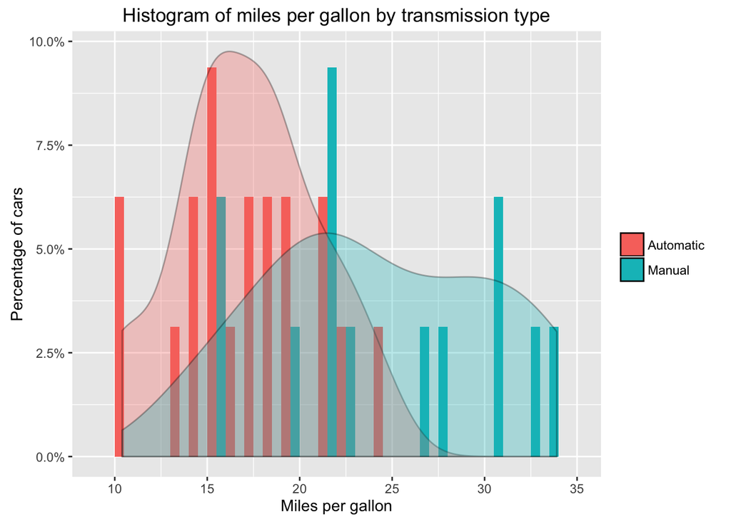

Now I carry out some regression modelling to answer the two questions. In all models, miles per gallon is the outcome variable. The reference category for transmission type (base category) is automatic.

In the first model, I control just for transmission type. The model output shwos that, holding all else constant, transmission type is significantly associated with miles per gallon. A manual transmission gives an increase of 7.245 miles per gallon compared to an automatic transmission.

```r
fit1 <- lm(mpg ~ am, data = cars)
summary(fit1)
```

```
##
## Call:
## lm(formula = mpg ~ am, data = cars)
##
## Residuals:
##     Min      1Q  Median      3Q     Max
## -9.3923 -3.0923 -0.2974  3.2439  9.5077
##
## Coefficients:
##             Estimate Std. Error t value Pr(>|t|)
## (Intercept)   17.147      1.125  15.247 1.13e-15 ***
## am             7.245      1.764   4.106 0.000285 ***
## ---
## Signif. codes:  0 '***' 0.001 '**' 0.01 '*' 0.05 '.' 0.1 ' ' 1
##
## Residual standard error: 4.902 on 30 degrees of freedom
## Multiple R-squared:  0.3598, Adjusted R-squared:  0.3385
## F-statistic: 16.86 on 1 and 30 DF,  p-value: 0.000285
```

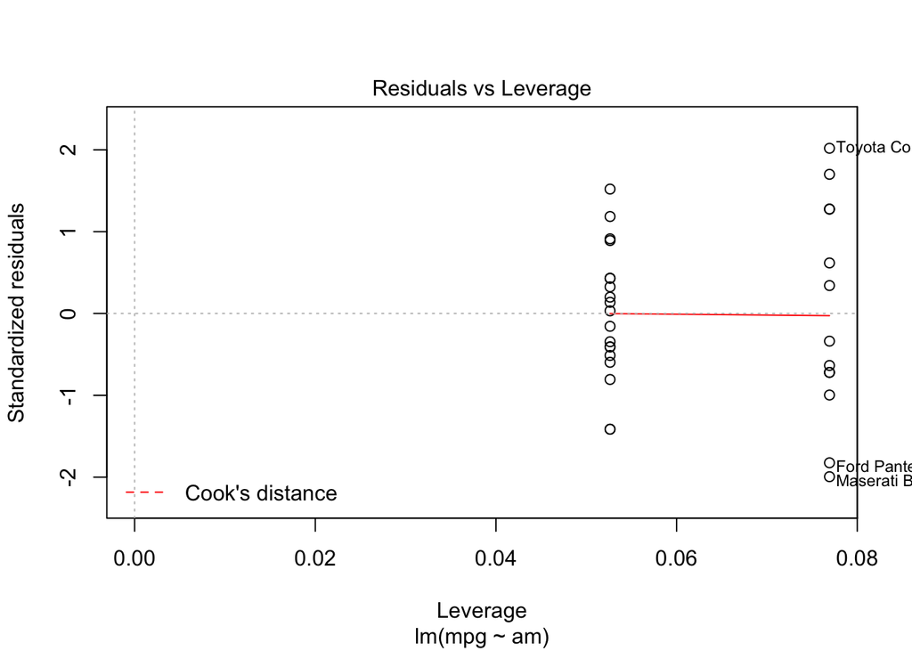

```r
# check model diagnostics
# influence.measures(fit1)
plot(fit1, which = 5) # there are three cars that have high leverage compared to their residuals
```

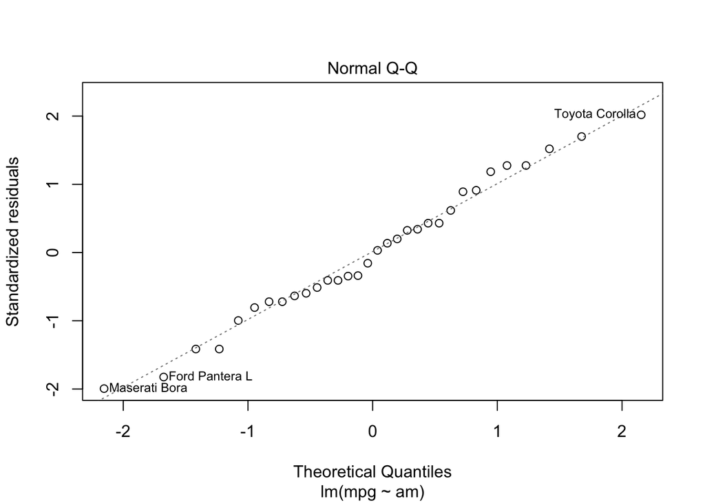

```r
plot(fit1, which = 2) # QQ plot shows three outlier cars
```

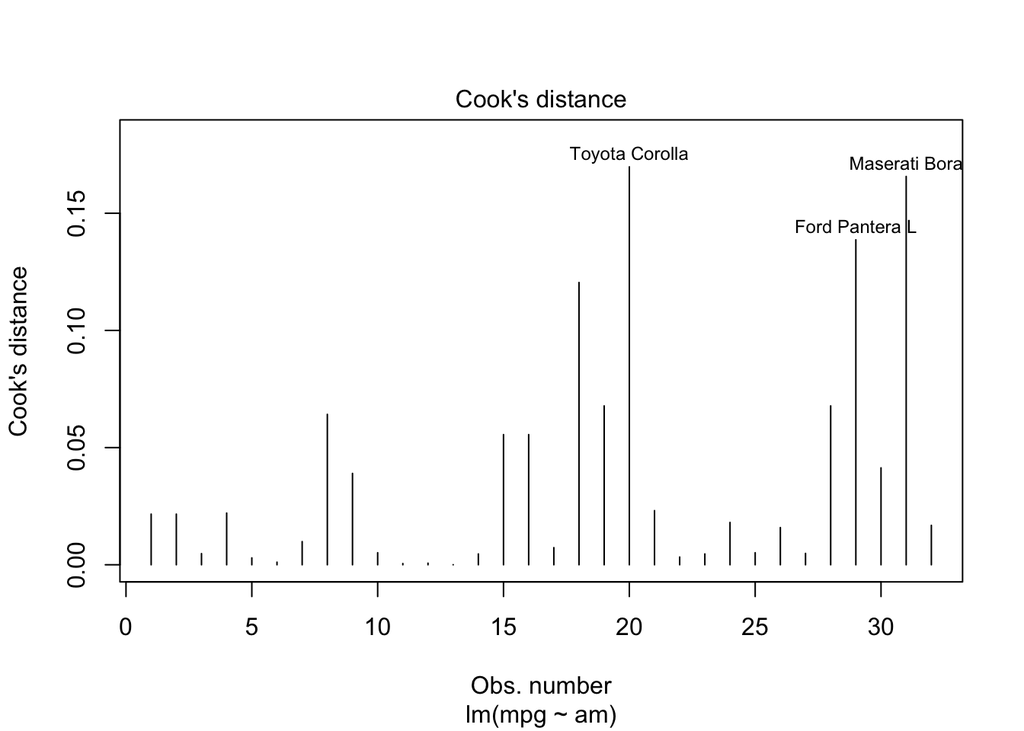

```r
plot(fit1, which = 4) # cook's distance
```

```r
# create a new dataset that removes these three outliers
library(dplyr)
cars$carname <- row.names(cars)
cars$dfbeta_fit1 <- round(dfbetas(fit1)[,2],3) # get the dfbetas for transmission variable
summary(cars$dfbeta_fit1) # see the min and max of the dfbetas
```

```
##       Min.    1st Qu.     Median       Mean    3rd Qu.       Max.
## -0.4680000 -0.1378000 -0.0125000  0.0000938  0.0967500  0.4750000
```

```r
cars_no <- filter(cars, (cars$dfbeta_fit1 < 0.4 & cars$dfbeta_fit1 > -0.4)) # remove the outlier cases according to their extreme dfbeta values
```

```r
# load packages for making the model table
library(memisc)
library(pander)

fit2 <- lm(mpg ~ am, data = cars_no)
fit3 <- lm(mpg ~ am + factor(cyl), data = cars_no)
fit4 <- lm(mpg ~ am + factor(cyl) + I(wt - mean(wt)), data = cars_no)

mytable123 <- mtable('Model 1' = fit2,
                     'Model 2' = fit3,
                     'Model 3' = fit4,
            summary.stats = c('R-squared','F','p','N'))
```

```r
library(texreg)
htmlreg(list(fit2, fit3, fit4), doctype = F, html.tag = F, inline.css = T,
    head.tag = F, body.tag = F, center = F, single.row = T, caption = "")
```

[output not shown]

[output cut: 11 more lines]

[output not shown]

```r
# check model fit
anova(fit2, fit3, fit4)
```

```
## Analysis of Variance Table
##
## Model 1: mpg ~ am
## Model 2: mpg ~ am + factor(cyl)
## Model 3: mpg ~ am + factor(cyl) + I(wt - mean(wt))
##   Res.Df    RSS Df Sum of Sq      F    Pr(>F)
## 1     27 461.27
## 2     25 207.91  2   253.366 22.146 3.549e-06 ***
## 3     24 137.29  1    70.618 12.345  0.001781 **
## ---
## Signif. codes:  0 '***' 0.001 '**' 0.01 '*' 0.05 '.' 0.1 ' ' 1
```